# # WHITE WINE DATA SET ANALYSIS BY `MOSTAFA TAREK`

### load the data set

first six rows

```
##   fixed.acidity volatile.acidity citric.acid residual.sugar chlorides
## 1           7.0             0.27        0.36           20.7     0.045
## 2           6.3             0.30        0.34            1.6     0.049
## 3           8.1             0.28        0.40            6.9     0.050
## 4           7.2             0.23        0.32            8.5     0.058
## 5           7.2             0.23        0.32            8.5     0.058
## 6           8.1             0.28        0.40            6.9     0.050
##   free.sulfur.dioxide total.sulfur.dioxide density   pH sulphates alcohol
## 1                  45                  170  1.0010 3.00      0.45     8.8
## 2                  14                  132  0.9940 3.30      0.49     9.5
## 3                  30                   97  0.9951 3.26      0.44    10.1
## 4                  47                  186  0.9956 3.19      0.40     9.9
## 5                  47                  186  0.9956 3.19      0.40     9.9
## 6                  30                   97  0.9951 3.26      0.44    10.1
##   quality
## 1       6
## 2       6
## 3       6
## 4       6
## 5       6
## 6       6
```

more details using str and summary functions on the data set

```
## 'data.frame':    4898 obs. of  12 variables:
##  $ fixed.acidity       : num  7 6.3 8.1 7.2 7.2 8.1 6.2 7 6.3 8.1 ...
##  $ volatile.acidity    : num  0.27 0.3 0.28 0.23 0.23 0.28 0.32 0.27 0.3 0.22 ...
##  $ citric.acid         : num  0.36 0.34 0.4 0.32 0.32 0.4 0.16 0.36 0.34 0.43 ...
##  $ residual.sugar      : num  20.7 1.6 6.9 8.5 8.5 6.9 7 20.7 1.6 1.5 ...
##  $ chlorides           : num  0.045 0.049 0.05 0.058 0.058 0.05 0.045 0.045 0.049 0.044 ...
##  $ free.sulfur.dioxide : num  45 14 30 47 47 30 30 45 14 28 ...
##  $ total.sulfur.dioxide: num  170 132 97 186 186 97 136 170 132 129 ...
##  $ density             : num  1.001 0.994 0.995 0.996 0.996 ...
##  $ pH                  : num  3 3.3 3.26 3.19 3.19 3.26 3.18 3 3.3 3.22 ...
##  $ sulphates           : num  0.45 0.49 0.44 0.4 0.4 0.44 0.47 0.45 0.49 0.45 ...
##  $ alcohol             : num  8.8 9.5 10.1 9.9 9.9 10.1 9.6 8.8 9.5 11 ...
##  $ quality             : int  6 6 6 6 6 6 6 6 6 6 ...
```

```
##  fixed.acidity    volatile.acidity  citric.acid     residual.sugar
##  Min.   : 3.800   Min.   :0.0800   Min.   :0.0000   Min.   : 0.600
##  1st Qu.: 6.300   1st Qu.:0.2100   1st Qu.:0.2700   1st Qu.: 1.700
##  Median : 6.800   Median :0.2600   Median :0.3200   Median : 5.200
##  Mean   : 6.855   Mean   :0.2782   Mean   :0.3342   Mean   : 6.391
##  3rd Qu.: 7.300   3rd Qu.:0.3200   3rd Qu.:0.3900   3rd Qu.: 9.900
##  Max.   :14.200   Max.   :1.1000   Max.   :1.6600   Max.   :65.800
##    chlorides       free.sulfur.dioxide total.sulfur.dioxide
##  Min.   :0.00900   Min.   :  2.00      Min.   :  9.0
##  1st Qu.:0.03600   1st Qu.: 23.00      1st Qu.:108.0
##  Median :0.04300   Median : 34.00      Median :134.0
##  Mean   :0.04577   Mean   : 35.31      Mean   :138.4
##  3rd Qu.:0.05000   3rd Qu.: 46.00      3rd Qu.:167.0
##  Max.   :0.34600   Max.   :289.00      Max.   :440.0
##     density             pH          sulphates         alcohol
##  Min.   :0.9871   Min.   :2.720   Min.   :0.2200   Min.   : 8.00
##  1st Qu.:0.9917   1st Qu.:3.090   1st Qu.:0.4100   1st Qu.: 9.50
##  Median :0.9937   Median :3.180   Median :0.4700   Median :10.40
##  Mean   :0.9940   Mean   :3.188   Mean   :0.4898   Mean   :10.51
##  3rd Qu.:0.9961   3rd Qu.:3.280   3rd Qu.:0.5500   3rd Qu.:11.40
##  Max.   :1.0390   Max.   :3.820   Max.   :1.0800   Max.   :14.20
##     quality
##  Min.   :3.000
##  1st Qu.:5.000
##  Median :6.000
##  Mean   :5.878
##  3rd Qu.:6.000
##  Max.   :9.000
```

this data set contains 11 independant variables and one response variable (quality) and 4898 observations

# Univariate Plots Section

i will analysis the independent vars

#### fixed acidity

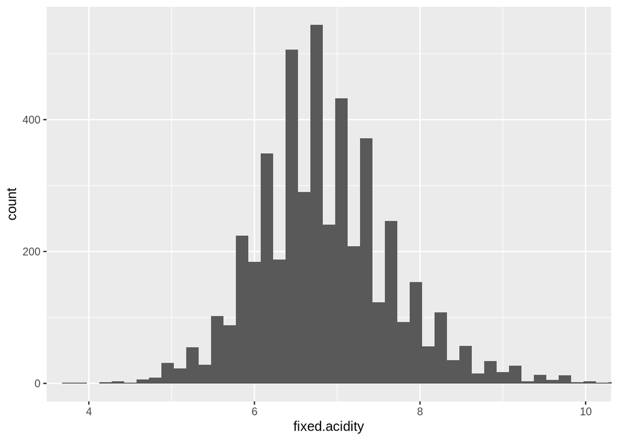

normal distribution

```
##    Min. 1st Qu.  Median    Mean 3rd Qu.    Max.
##   3.800   6.300   6.800   6.855   7.300  14.200
```

summary of fixed.acidity

#### volatile.acidity

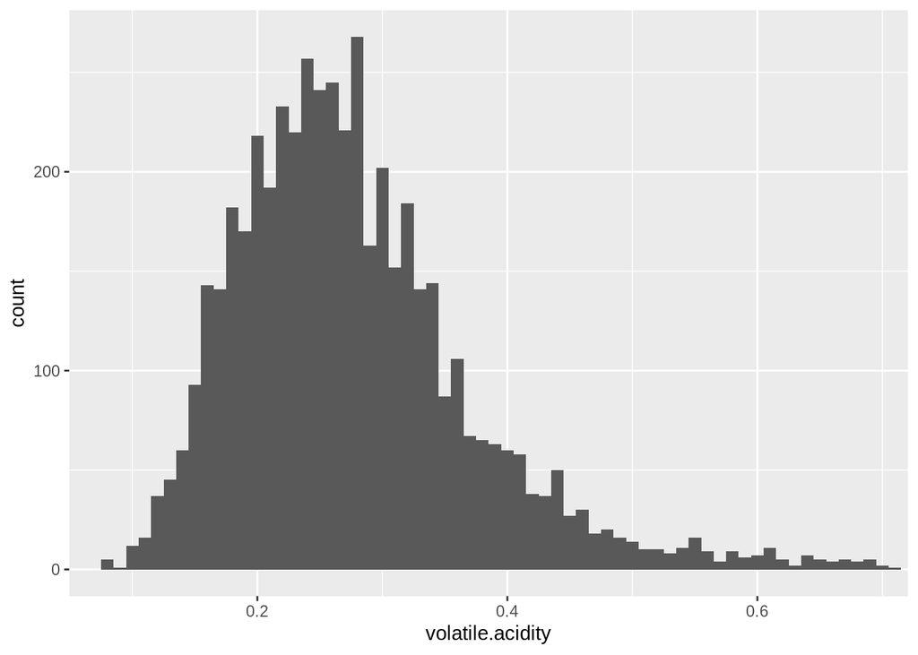

almost normal distribution

```
##    Min. 1st Qu.  Median    Mean 3rd Qu.    Max.
##  0.0800  0.2100  0.2600  0.2782  0.3200  1.1000
```

summary of volatile acidity

#### citric.acid

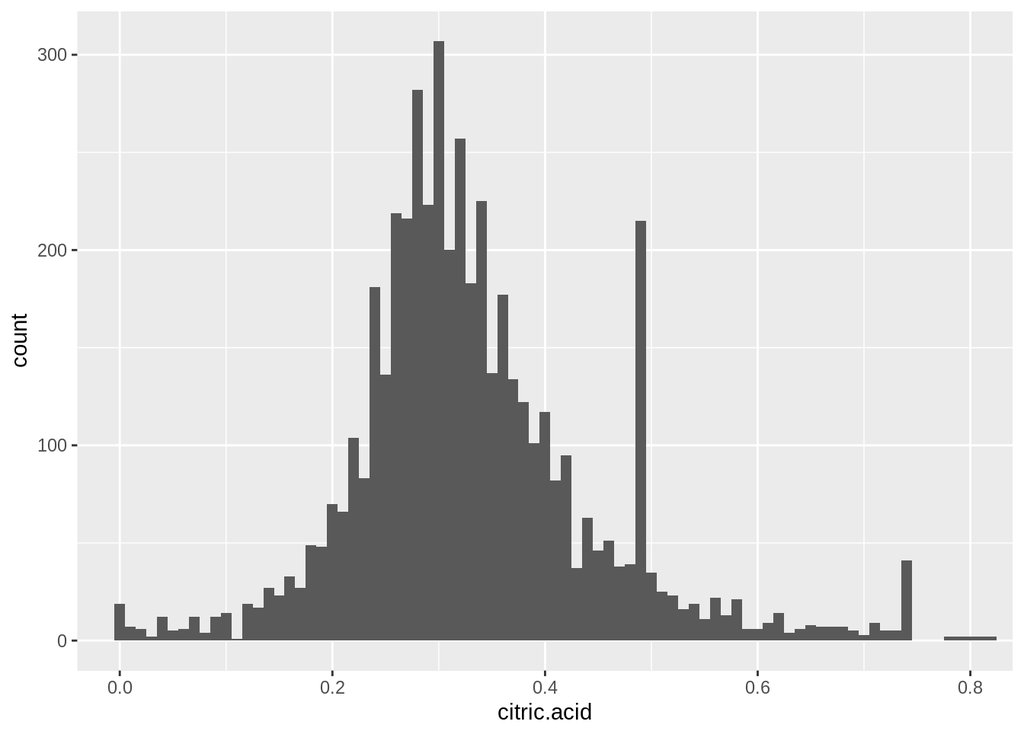

normal distribution

```
##    Min. 1st Qu.  Median    Mean 3rd Qu.    Max.
##  0.0000  0.2700  0.3200  0.3342  0.3900  1.6600
```

summary of citric acid

#### residual.sugar

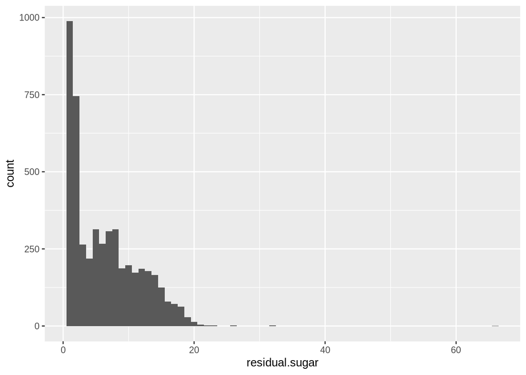

right skewed

transform x axis to log base ten to make it normal distribution so that it will be appropriate asssumption for linear models

so :

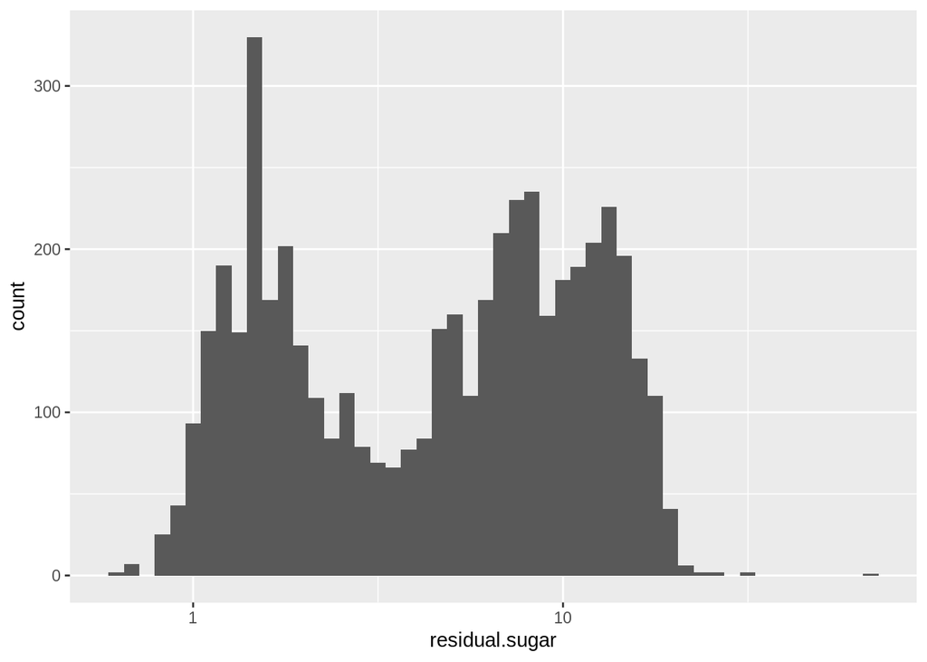

bimodal distribution

```
##    Min. 1st Qu.  Median    Mean 3rd Qu.    Max.
##   0.600   1.700   5.200   6.391   9.900  65.800
```

summary of residual sugar

#### chlorides

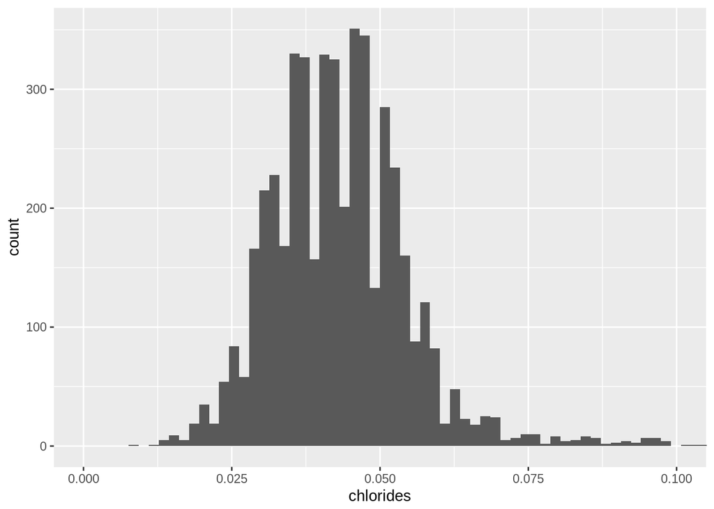

normal distribution

```
##    Min. 1st Qu.  Median    Mean 3rd Qu.    Max.
## 0.00900 0.03600 0.04300 0.04577 0.05000 0.34600
```

summary of chlorides

#### free.sulfur.dioxide

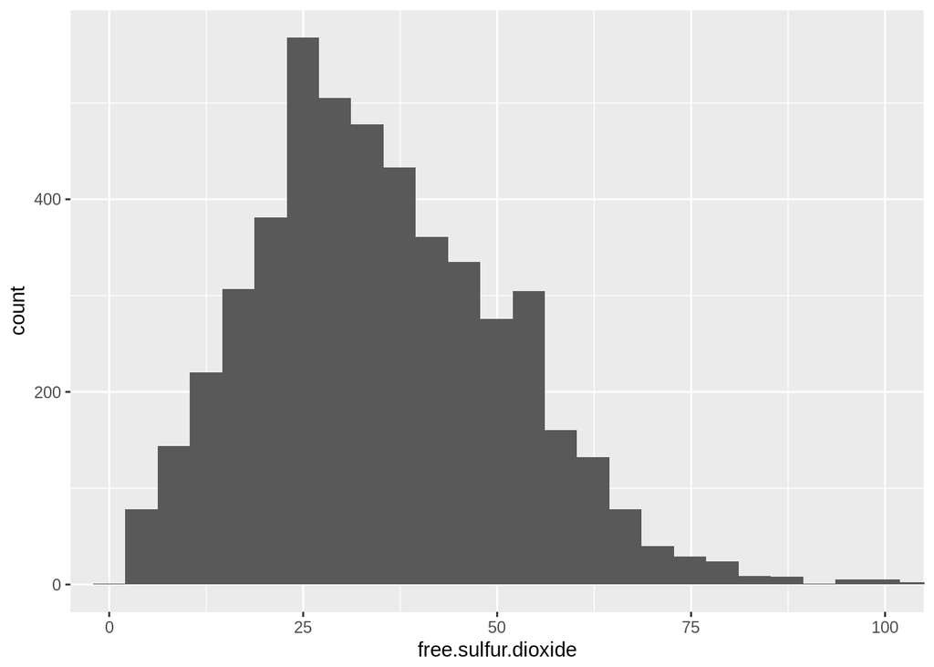

normal distribution

```
##    Min. 1st Qu.  Median    Mean 3rd Qu.    Max.
##    2.00   23.00   34.00   35.31   46.00  289.00
```

summary of free sulfur dioxide

#### total.sulfur.dioxide

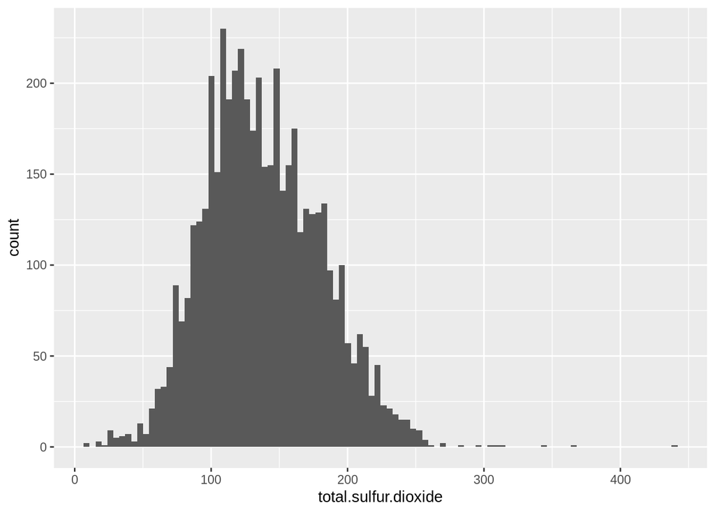

normal distribtution

```
##    Min. 1st Qu.  Median    Mean 3rd Qu.    Max.
##     9.0   108.0   134.0   138.4   167.0   440.0
```

summary of total sulfur dioxide

#### density

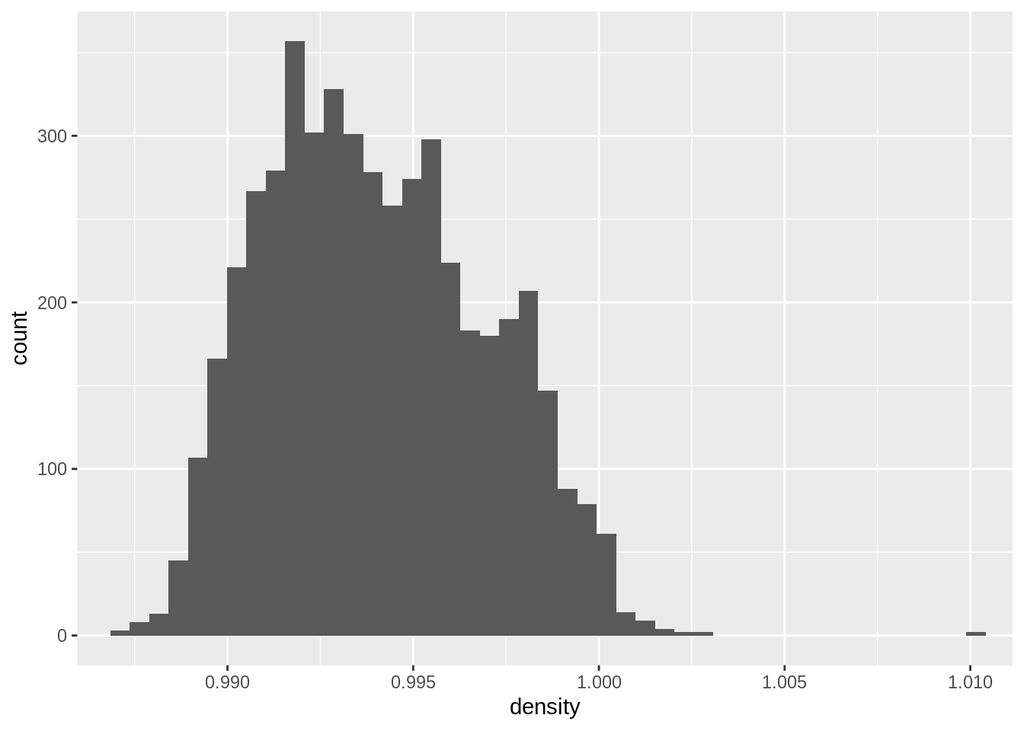

normal distribution

```
##    Min. 1st Qu.  Median    Mean 3rd Qu.    Max.
##  0.9871  0.9917  0.9937  0.9940  0.9961  1.0390
```

summary of density

#### pH

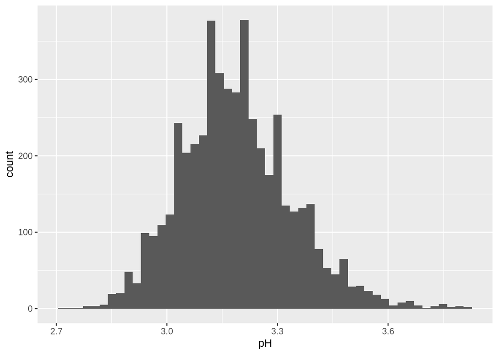

```
##    Min. 1st Qu.  Median    Mean 3rd Qu.    Max.
##   2.720   3.090   3.180   3.188   3.280   3.820
```

summary of pH

#### sulphates

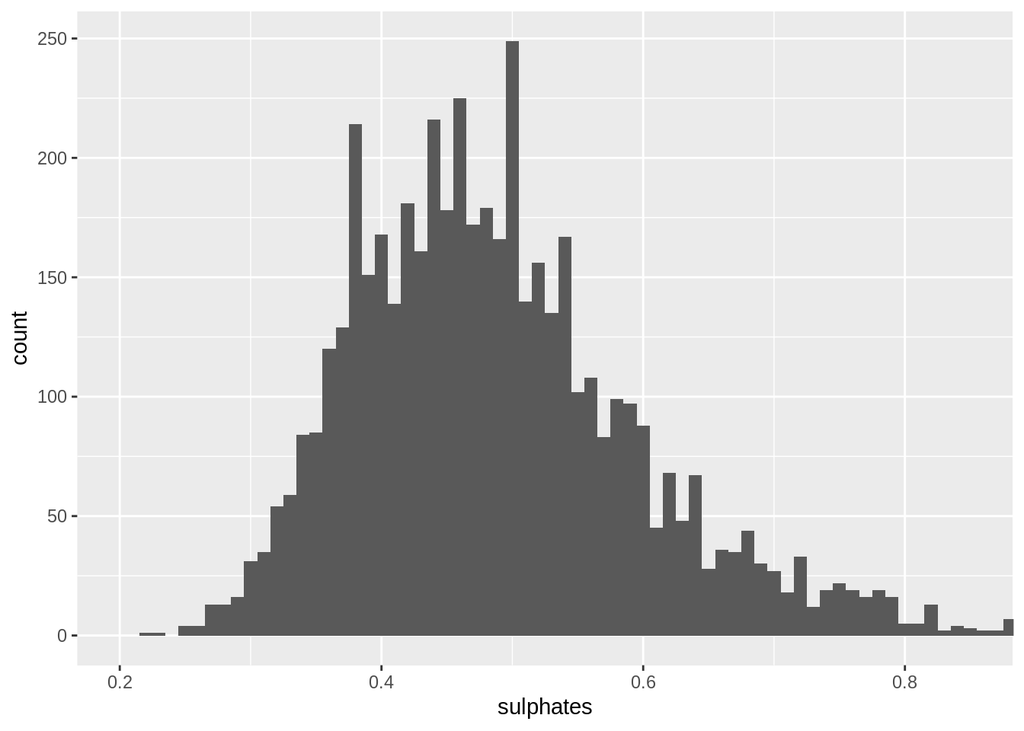

normal distibution

```
##    Min. 1st Qu.  Median    Mean 3rd Qu.    Max.
##  0.2200  0.4100  0.4700  0.4898  0.5500  1.0800
```

summary of sulphates

#### alcohol

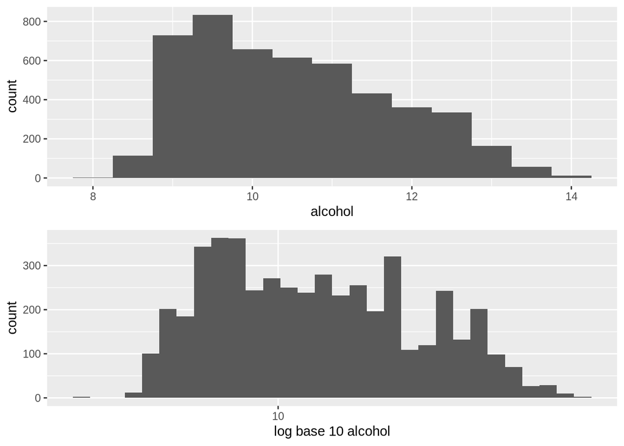

right skewed

and the second plot (the log base 10 for x axis) is slightly different than the orgnal plot so the alcohol will be write skewed

```
##    Min. 1st Qu.  Median    Mean 3rd Qu.    Max.
##    8.00    9.50   10.40   10.51   11.40   14.20
```

summary of alcohol

#### quality

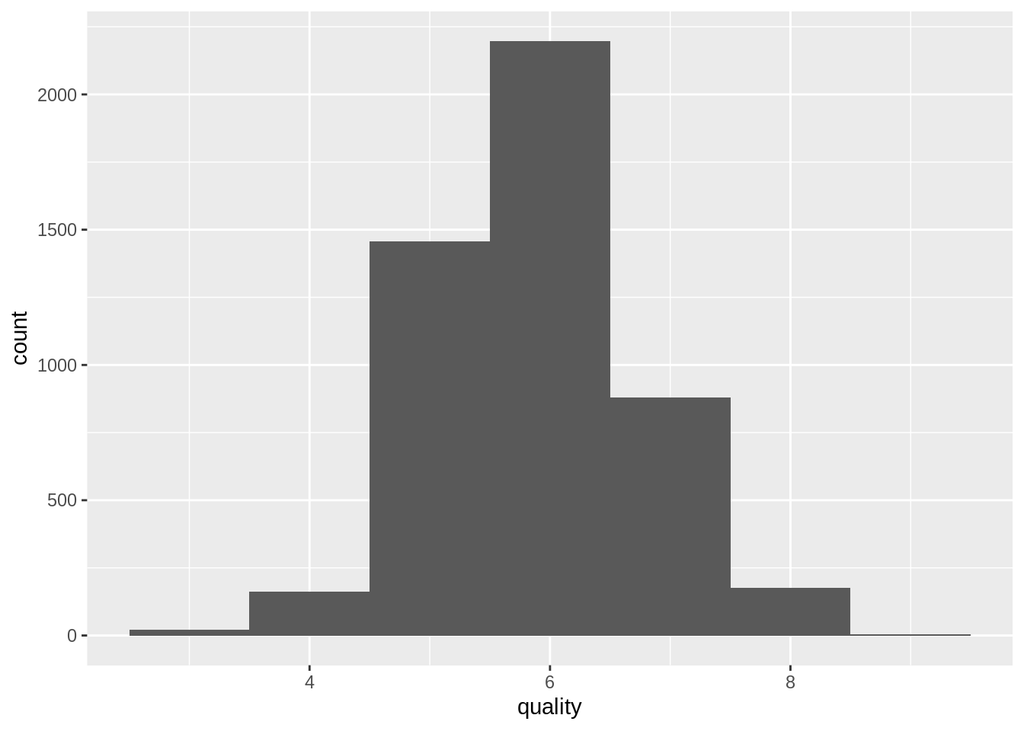

normal distribution

```
##    Min. 1st Qu.  Median    Mean 3rd Qu.    Max.
##   3.000   5.000   6.000   5.878   6.000   9.000
```

summary of quality

# Univariate Analysis

### What is the structure of your dataset?

The data set contains of

- 11 independant vars
- 1 response var (quality)
- 4898 observations of white wine quality

### What is/are the main feature(s) of interest in your dataset?

- most of the ind vars are normal distributions which is usefull for the linear models assumptions
- all of the ind var are almost normal distribution except
  - residual.sugar var is right skewed and then we take the log base 10 for x axis and it becomes modal distribution
  - alcohol is right skewed even after scale_x_log base 10 transformation

### What other features in the dataset do you think will help support your

investigation into your feature(s) of interest?

The correlation between the ind vars and response var and among themselves and I will cover this in the bivariant section

### Did you create any new variables from existing variables in the dataset?

no

### Of the features you investigated, were there any unusual distributions?

Did you perform any operations on the data to tidy, adjust, or change the form  
of the data? If so, why did you do this?

no I didn’t since the data is TIDY, CLEAN and good QUALITY

# Bivariate Plots Section

i will plot the correlation coefficients of between the each variable using pairs.panels with pearson method

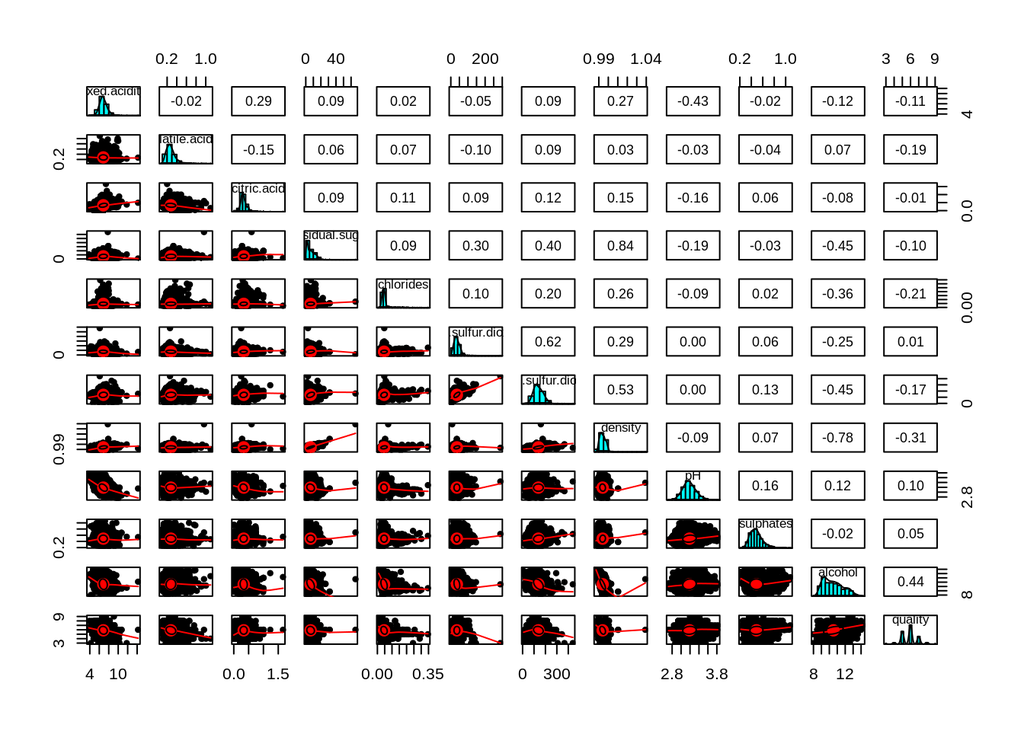

i will use the corrplot package and corrplot.mixed function to plot the correlations and its color

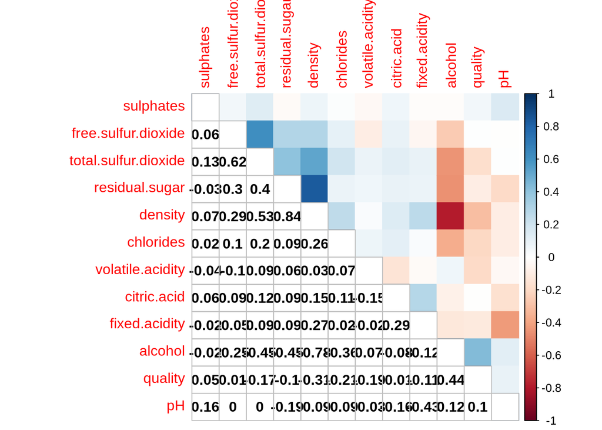

color indicates the correlation coefficients and it variate from blue (strong positive) to red (strong negative)

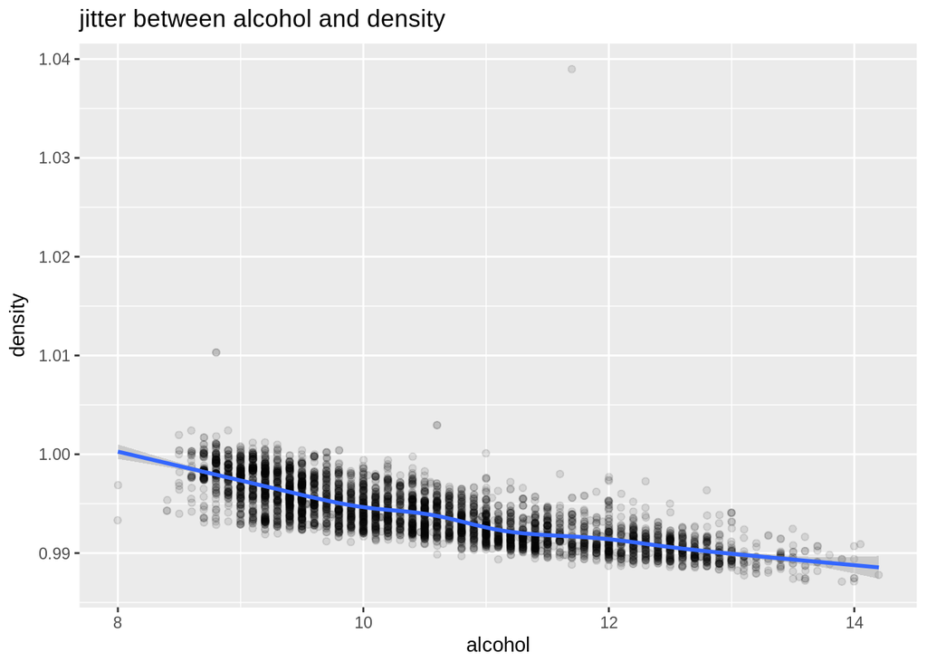

```
## [1] -0.7801376
```

correlation of density and alcohol

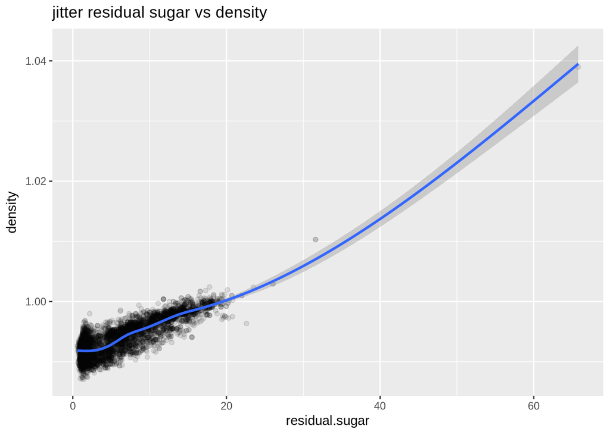

```
## [1] 0.8389665
```

correlation of density and residual sugar

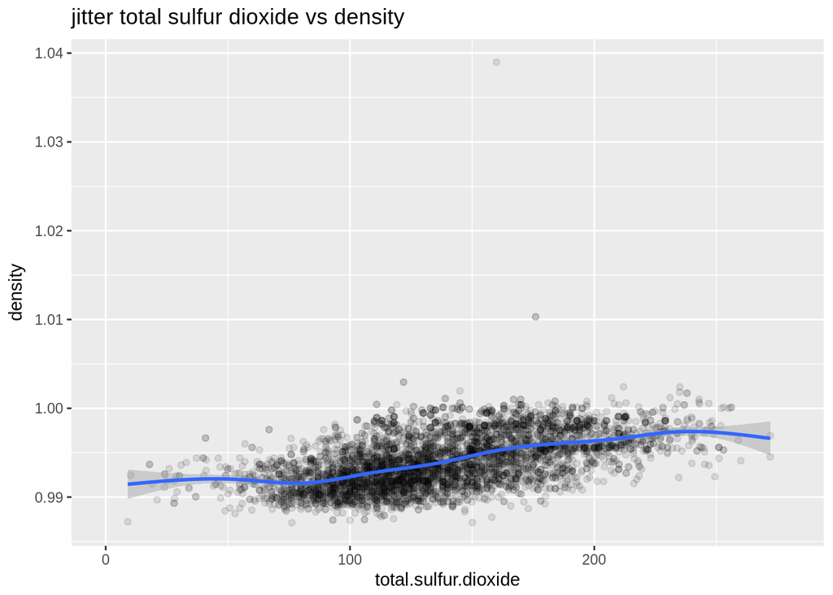

- density and total sulfur doxide have a strong positive relationship which make the colinearity problem (r = +.5)

```
## correlation 0.5298813
```

correlation of total sulfur dioxide and desity

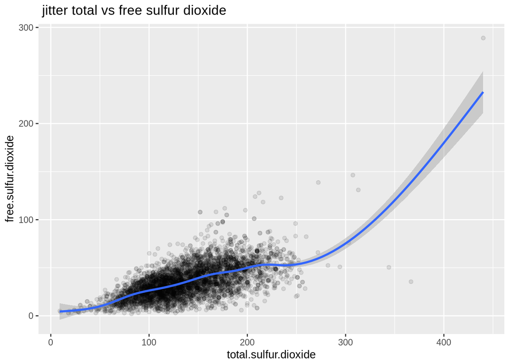

- free sulfur dioxide and total sulfur dioxide have a strong positive relationship which make the colinearity problem (r = +.62)

```
## [1] 0.615501
```

correlation of total and free sulfur dioxide

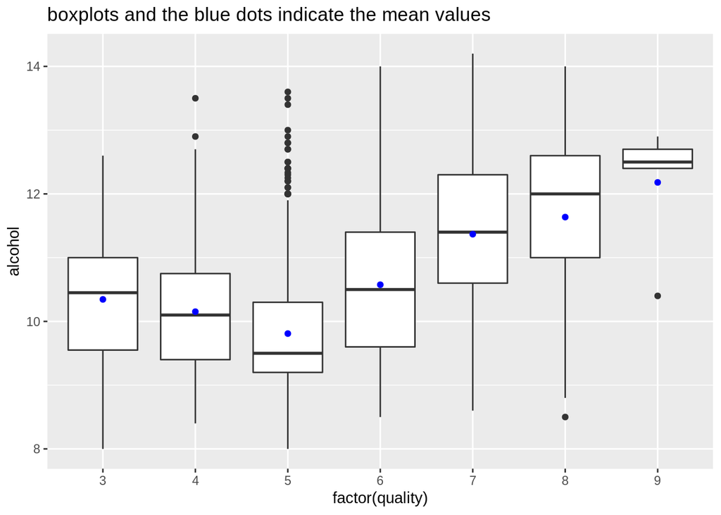

6 to 9 quality level have high alcohol level than 3 to 5 quality level

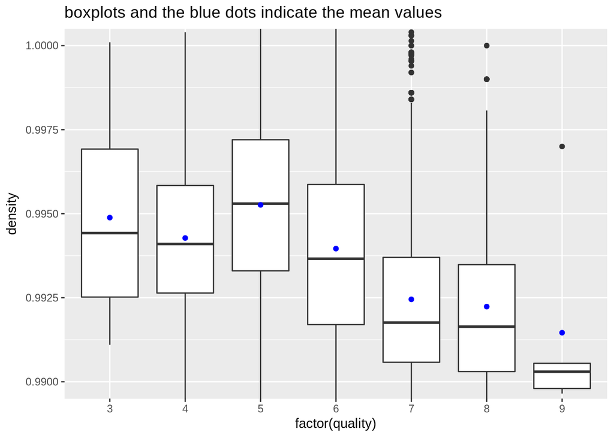

high quality has low density levels

# Bivariate Analysis

### Talk about some of the relationships you observed in this part of the

investigation. How did the feature(s) of interest vary with other features in  
the dataset?

I examined which components can influence the wine quality in the dataset and how strong is the correlation between quality and other features. I found out that alcohol content and density can play a lot more important role in quality.

### Did you observe any interesting relationships between the other features

(not the main feature(s) of interest)?

### What was the strongest relationship you found?

residual.sugar and density

# Multivariate Plots Section

i will use the geom point to plot the relation between residual sugar and density with the color = quality as categorical variable  
and the smooth method is ‘lm’

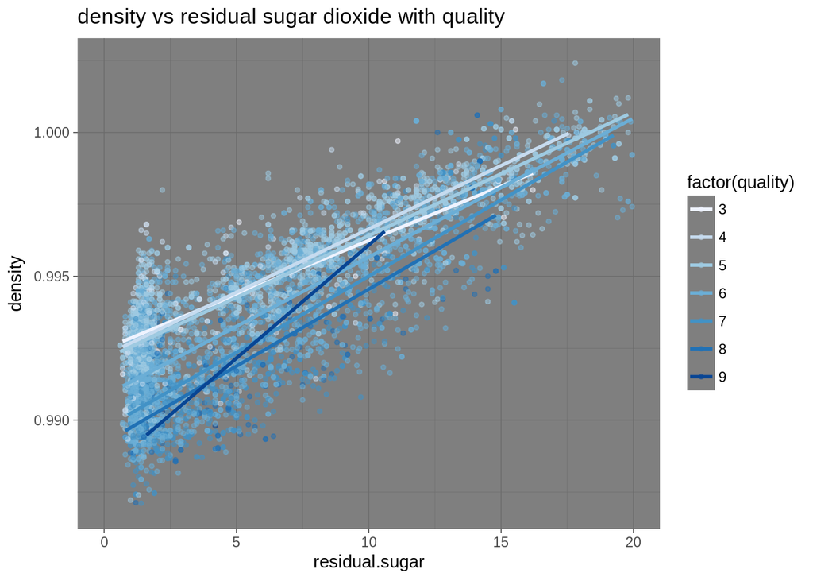

hight quality make the relation between density and residual sugar strong positive

i will use the geom point to plot the relation between total and free sulfur dioxide with the color = quality as categorical variable  
and the smooth method is ‘lm’

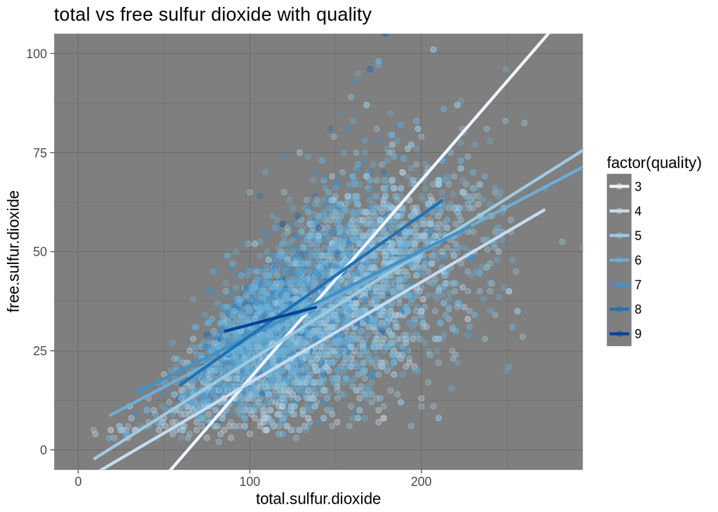

total sulfur dioxide and free sulfur dioxide have a week correlation coefficient in high quality (9)

# linear model

split the data to train test data sets with 80% and 20% respectively then bulid the three model and evaluate the min max accuracy for each model

```
##
## Calls:
## m1: lm(formula = quality ~ density + alcohol, data = trainingData)
## m2: lm(formula = quality ~ density + alcohol + chlorides + volatile.acidity +
##     fixed.acidity, data = trainingData)
## m3: lm(formula = quality ~ density + alcohol + chlorides + volatile.acidity +
##     fixed.acidity + free.sulfur.dioxide + total.sulfur.dioxide +
##     citric.acid + residual.sugar + sulphates + pH, data = trainingData)
##
## ==================================================================
##                              m1            m2            m3
## ------------------------------------------------------------------
##   (Intercept)             -23.435***    -48.447***    138.645***
##                            (6.753)       (6.784)      (20.009)
##   density                  25.714***     51.645***   -138.577***
##                            (6.659)       (6.721)      (20.300)
##   alcohol                   0.357***      0.404***      0.206***
##                            (0.016)       (0.017)       (0.026)
##   chlorides                              -1.221*       -0.204
##                                          (0.589)       (0.596)
##   volatile.acidity                       -2.101***     -1.900***
##                                          (0.122)       (0.125)
##   fixed.acidity                          -0.089***      0.067**
##                                          (0.015)       (0.023)
##   free.sulfur.dioxide                                   0.003***
##                                                        (0.001)
##   total.sulfur.dioxide                                 -0.000
##                                                        (0.000)
##   citric.acid                                          -0.043
##                                                        (0.105)
##   residual.sugar                                        0.078***
##                                                        (0.008)
##   sulphates                                             0.686***
##                                                        (0.110)
##   pH                                                    0.622***
##                                                        (0.116)
## ------------------------------------------------------------------
##   R-squared                 0.191         0.256         0.282
##   adj. R-squared            0.191         0.255         0.280
##   sigma                     0.791         0.759         0.746
##   F                       463.019       269.228       139.376
##   p                         0.000         0.000         0.000
##   Log-likelihood        -4638.376     -4474.967     -4405.660
##   Deviance               2448.390      2252.445      2174.149
##   AIC                    9284.753      8963.934      8837.319
##   BIC                    9309.846      9007.848      8918.873
##   N                      3918          3918          3918
## ==================================================================
```

```
##    actuals predicteds
## 7        6   5.468969
## 12       5   5.599630
## 20       5   5.503763
## 22       7   5.855407
## 24       5   4.492153
## 40       5   5.628761
```

summary of the three models and the first six rows of the predictions using model3

```
## [1] 0.8993466
```

```
## [1] 0.9042657
```

```
## [1] 0.9052759
```

accuracy of the three model 1 2 and 3 respectively

so to reduce the calculation time we use model 1 because model 2 and model 3 didn’t do so much in min max accuracy note:

m1 using features density , alcohol

m2 using features density , alcohol , chlorides , volatile.acidity , fixed.acidity

m3 using all features

# Multivariate Analysis

### Talk about some of the relationships you observed in this part of the

investigation. Were there features that strengthened each other in terms of  
looking at your feature(s) of interest?

residual sugar and density

### Were there any interesting or surprising interactions between features?

interaction between the residual sugar and density in high quality they are very correlated to one another

### OPTIONAL: Did you create any models with your dataset? Discuss the

strengths and limitations of your model.

srengths > min max accuracy is 90%

limitations > the output is continous not discrete because i used a linear reg model not classification model like logistic reg

# Final Plots and Summary

### Plot One

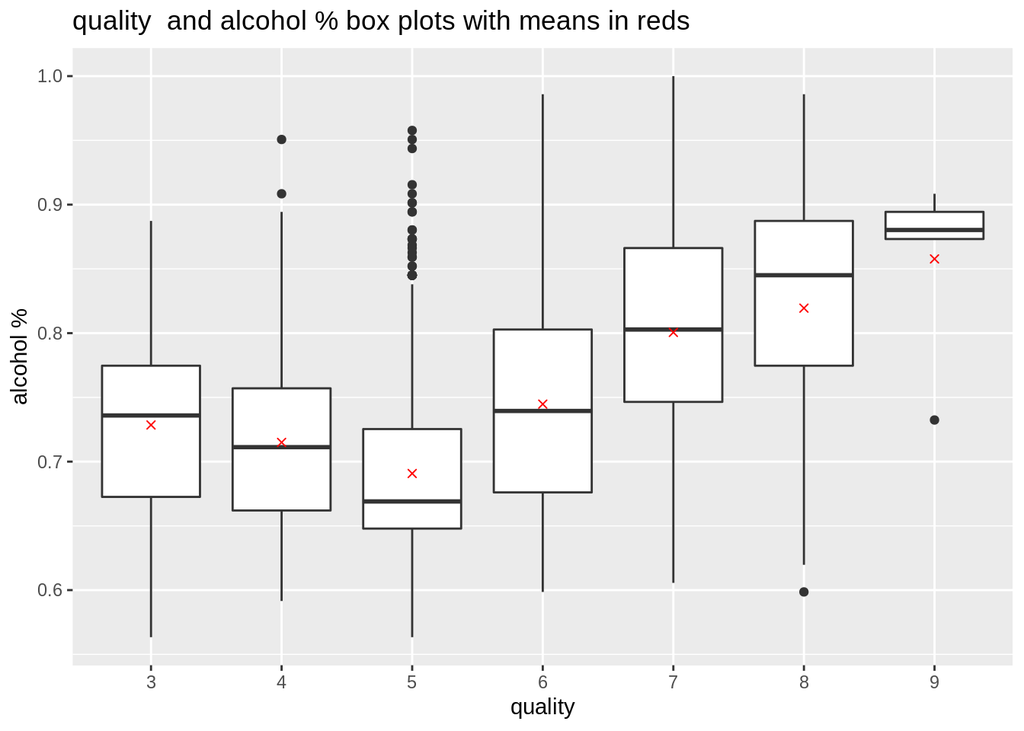

### Description One

in quality 6, 7, 8, and 9 the alcohol level is higher than the quality in levels 3, 4 and 5

the red dots indicate the mean value of each quality level

### Plot Two

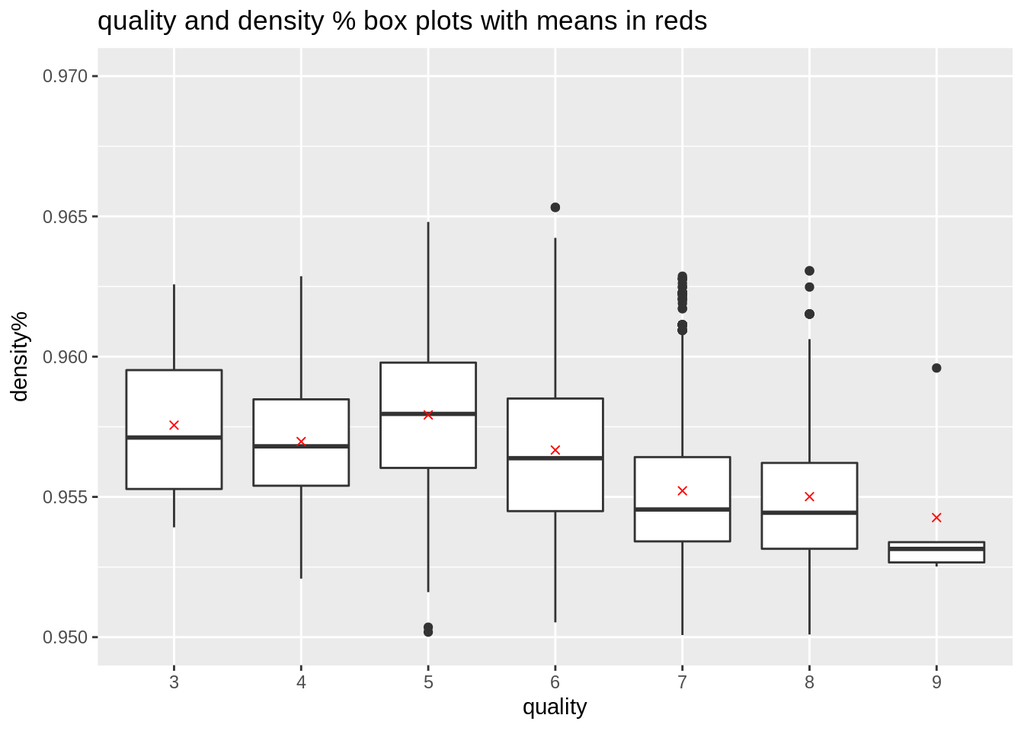

### Description Two

in quality 6, 7, 8, and 9 the density level is lower than the quality in levels 3, 4 and 5

the red dots indicate the mean value of each quality level

### Plot Three

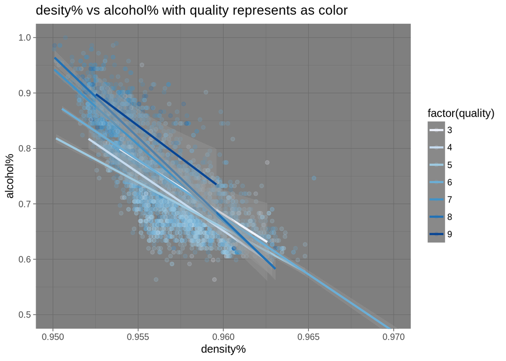

### Description Three

the density and alcohol have an inverse relationship

in the high quality the alcohol level for specific density value is larger than the alcohol level in lower quality

## in other words in the same density value, the more alcohol level we get the more quality the wine tend to be

# Reflection

My main feature of interest was wine quality and I could find some variables which tend to influence this factor, like alcohol content and density. In the first part I made some simple hitograms about the main factors and other variables as well. In the part of bivariate analysis, I tried to get a better knowledge on the factors which influence wine quality. I was suprised that residual sugar, pH, citric acid and fixed acidity do not correlate with wine quality.

i could make some other interesting explorations in the future, like trying another models for fit the data well like non linear regression model

or using classification models with output from 3 to 9

The project work took me more time than I previously estimated

It took time to choose the best corresponding plots and to detect the variables that influence quality. I had to examine each variable separatly while not forgetting the whole picture which I found really challenging and exciting.